# My Statistical Breakdown of Immaculate Grid Success

Anthony Griffith

2025-01-24

# What is the Immaculate Grid?

The Immaculate Grid is an online web browser game that has become increasingly popular over the past year. It is a 3x3 grid with 9 different squares to input players. The object of the game is to guess players that qualify for each square combination. To make things more challenging, you only get nine guesses to complete the entire grid.

The goal is to not only find players that meet the requirements for each square, but to find players that many people will not think of. Each correct guess gets a “rarity score,” and your total score is a summation of all nine separate scores. Each incomplete grid is worth 100 points; the lower your overall score is, the better you performed.

# Background & Project Questions

There are two very common questions that I and many other players of the Immaculate Grid game often ask:

1. What teams and categories cause me the most trouble and tend to make my score worse?
2. Is there any specific reason as to why these teams and categories inflate my numbers?

While these may seem like general questions, they are critical in trying to understand what makes us struggle and succeed at this game. So, I decided to take my own scores and complie some thoughts as to what may be causing these troubles.

In order to collect the data, I completed every grid in the month of July 2023 and collected the following numbers: overall score, teams, categories, the amount of appearances for those teams and categories, and the average score for each of them.

# Daily Grid Scores

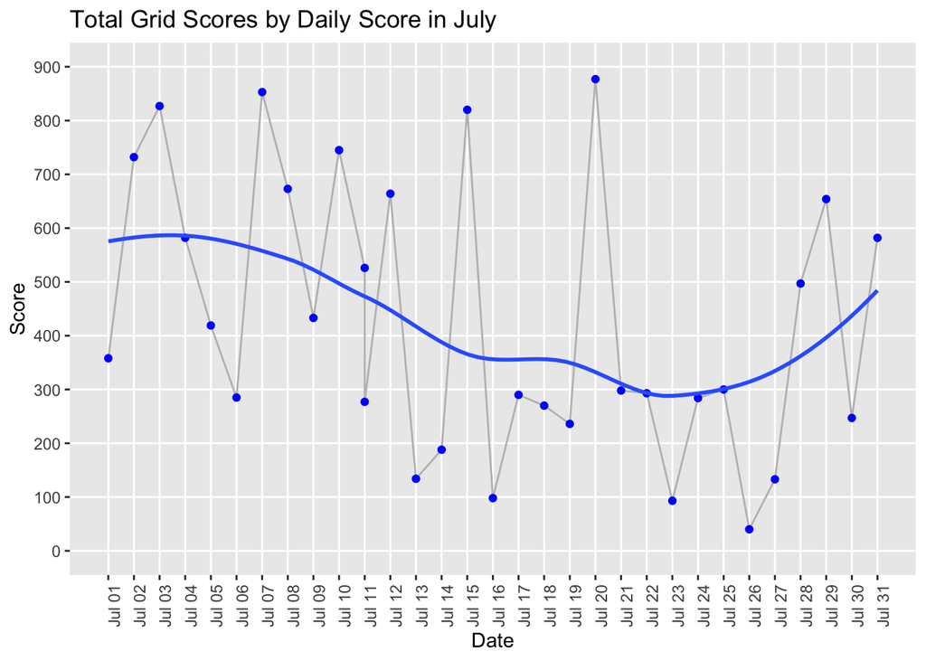

As you can see here, my scores varied pretty drastically day by day. However, it is worth noting that my average score decreased in the middle of the month, but increased towards the end of it. Since my average score was the highest at the beginning of July, I do want to look at the scores that are above 700, since those tend to have the greatest negative impact.

# Assessment of Teams

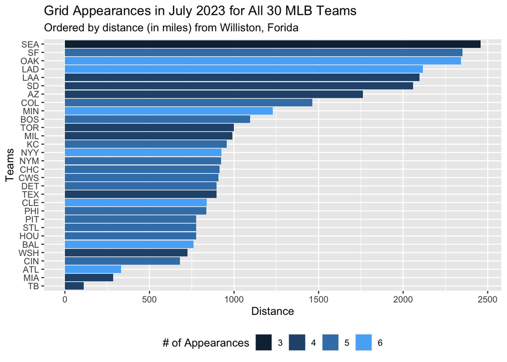

This graph shows the mileage between my hometown and the location of every team’s stadium, along with the number of times they have appeared. My main reason for starting with this kind of graph is that I wanted to try and see if there was any connection between my location and the number of times a team appeared on a grid. As you can tell, it looks like the teams are chosen at random, so I decided to dive a little deeper.

## Team Scoring

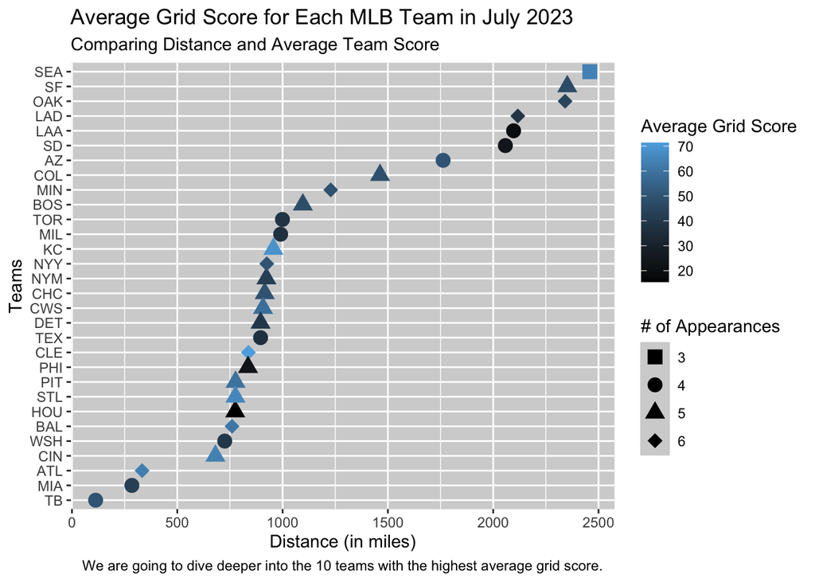

Now this graph still shows the distance in miles and the number of appearances, but now it adds in my average grid score for each team. I wanted to see if mileage plays any sort of factor in my success or failures for teams. You will notice that teams with a high average grid score have a much brighter point color on the graph. I’ve decided to choose the ten teams with the worst average score and dive into those teams specifically. The teams I am looking at are the Atlanta Braves, Baltimore Orioles, New York Yankees, Cincinnati Reds, Cleveland Guardians, Seattle Mariners, Pittsburgh Pirates, Chicago White Sox, St. Louis Cardinals, and Kansas City Royals.

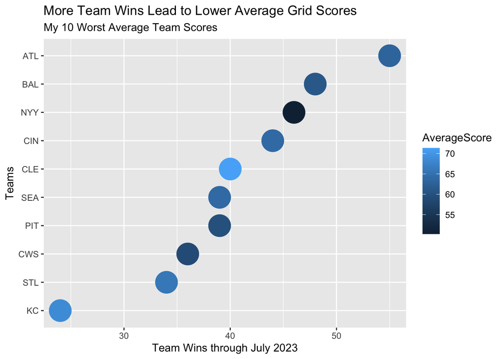

## Takeaways

Surprisingly, there is no definite trend where geographical location and distance apart from teams will increase/decrease scores. However, my top ten worst teams’ average scores were slightly dependent on team wins through July 2023. I think this is directly caused by the amount of success and real life publicity that teams can have. When teams win, they get more publicity. More publicity leads to more player knowledge, and more player knowledge leads to lower scores. Another factor that I wanted to try and take into account was the amount of times that each team appeared on the grid, but the number of appearances on the grid don’t seem to have a massive impact on scores either, since almost every team appears around 4-6 times.

# Assessment of Milestones

Before I start showing the milestone data, there is something to note here. I’ve placed each milestone into it’s own category; it is either an award or a statistic. An award is a title or physical achievement that a player can earn over the course of their career. A statistic is a numerical highlight that is achieved. For example, having a season with 200 or more strikeouts is a statistic, but winning a Cy Young for that season is an award.

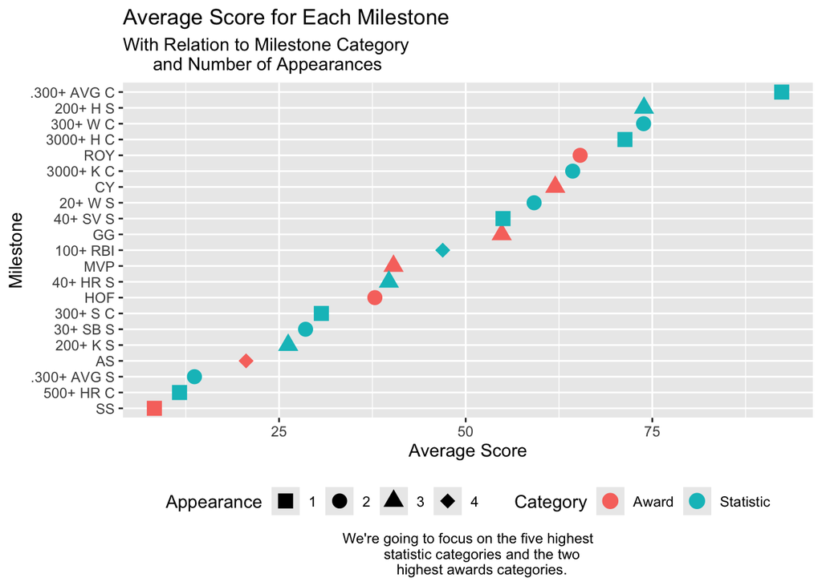

This graph shows my average score for each milestone, as well as how many times they appeared on the grid. Although more statistics appear on the grid as opposed to awards, it still seems like there is an even split between how many times a given milestone will appear. In order to make the rest of the exploration equal, I’m going to choose the five statistics and two awards with the highest average grid scores. The five statistics are .300+ career batting average, 200+ hits in a season, 300+ career pitching wins, 3000+ career batting hits, and 3000+ career pitching strikeouts; the two awards are Rookie of the Year and Cy Young.

[figure not shown]

## Takeaways

Unlike teams, the number of appearances play a decently sized role when it comes to the milestones. However, the kind of milestone also comes into play as well. It seems as if any kind of career statistical landmark (e.g. .300+ AVG C, 3000+ H C, 3000+ K C) poses more of a challenge than a seasonal statistical achievement (e.g. 30+ SB S, 200+ K S, .300+ AVG S), which is just due to the fact that seasonal achievements happen more often than career ones do; you would have to retire with certain landmarks for them to be considered final and unchangeable.

Although, I did notice that the number of appearances do have more of an effect on seasonal awards (e.g. CY, GG). These awards don’t come around until the end of the season. A six-to-seven month time span from the end of the last season to the middle of the next season leaves a lot of room to forget people’s achievements. Although, if you can remember them, they do a good amount of work in making scores better.

# Final Thoughts

This project, in my eyes, was very interesting to create. I had to put the data into tables by hand and then be able to make the graphics in order to find relationships. On top of that, a lot of the relationships I expected to find didn’t really end up making much of a difference at all. While some of these assumptions you could make on your own, it was still pretty cool to be able to physically see the multiple relationships that can lead to good and bad scores on this game.

As the game continues to grow (the website already has grids for more professional sports), more and more people are going to be asking the same questions I did. In my eyes, that’s an awesome problem to have because it forces people to keep coming back, while also helping them learn more about sports history in a way that’s engaging and entertaining.